# About_this_study

## Study summary

### Abstract

We address the issue of adapting landscapes for improved insect biodiversity conservation in a changing climate by assessing the importance of additive (main) and synergistic (interaction) effects of land cover and land use with climate.

We test the hypotheses that ant richness (species and genus), abundance and diversity would vary according to land cover and land use intensity but that these effects would vary according to climate.

We used a 1000 m elevation gradient in eastern Australia (as a proxy for a climate gradient) and sampled ant biodiversity along this gradient from sites with variable land cover and land use. Results Main effects revealed: higher ant richness (species and genus) and diversity with greater native woody plant canopy cover; and lower species richness with higher cultivation and grazing intensity, bare ground and exotic plant groundcover. Interaction effects revealed: both the positive effects of native plant canopy cover on ant species richness and abundance, and the negative effects of exotic plant groundcover on species richness were greatest at sites with warmer and drier climates.

Impacts of climate change on insect biodiversity may be mitigated to some degree through landscape adaptation by increasing woody native vegetation cover and by reducing land use intensity, the cover of exotic vegetation and of bare ground.Evidence of synergistic effects suggests that landscape adaptation may be most effective in areas which are currently warmer and drier, or are projected to become so as a result of climate change.

### Keywords

Climate change, Landscape adaptation, Land cover, Land use, Synergistic effects, Biodiversity,Insects, Ants,Species richness, Species turnover

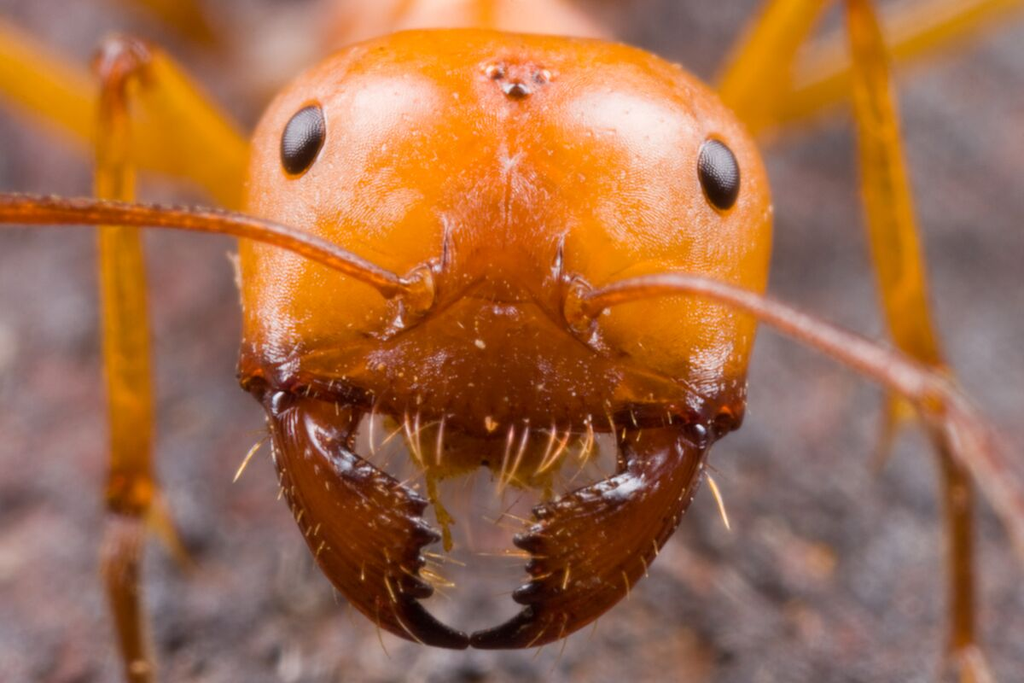